# Morfologia, luento 16

Juho Härme

Pinni B 5004, juho.harme@uta.fi

# Viime tunnilta

Tehtävä aspektipareista

# Konkreettis-prosessuaalinen merkitys

- Когда мама пришла домой, я *играл* на фортепиано
- Сижу дома на кухне и занимаюсь китайским.
- Он *думал*, *думал*, *думал*, и *чувствовал*, что голова у него *раздувается* точно воздушный шар.
- Молодая женщина *сидела* у окна вагона и *читала*
- Она *сидела* и *думала* и в голову ей приходила … только пустота
- Я *плакала* и *обнимала* дочку.

# Konkreettis-prosessuaalinen merkitys

[figure not shown]

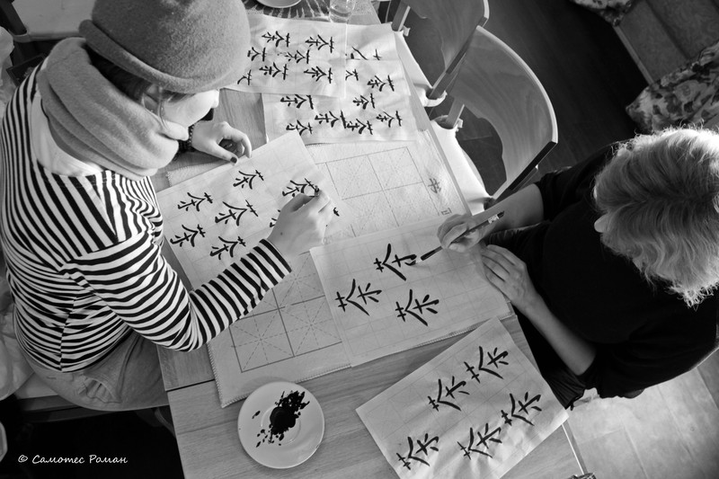

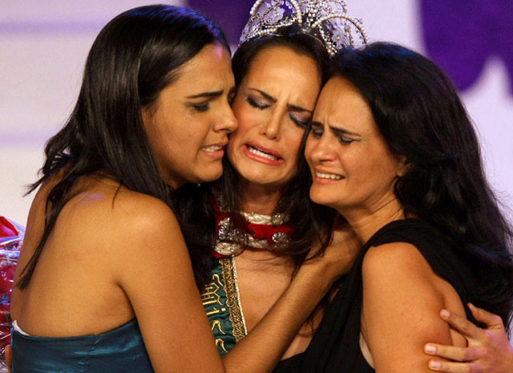

# Konkreettis-faktinen merkitys

- Она *повторила* мне свой вопрос.
- Бухгалтер *сделал* в учете запись.
- *Перешлю* ссылку на эту статью знакомым учителям.
- Я *заполз* под диван, *лег* ничком, *вынул* нож из кармана и *прорезал* в ситце дырку, чтоб удобно было подсматривать.

# Konkreettis-faktinen merkitys

[figure not shown]

[figure not shown]

# Toistoon liittyviä merkityksiä 1.

- Я часто покупаю на рынке овощи.
- В Финляндии всегда играют в хоккей.
- В Финляндии редко играют в футбол.
- Сайт постоянно пополняется новыми материалами

# Toistoon liittyviä merkityksiä 2.

- Я три раза поступал в университет.
- Мне это надоело. Три раза подогревал тебе суп.

# Toistoon liittyviä merkityksiä 3.

- Он несколько раз перечитал записку
- Вчера я пять раз прочитал материал для экзамена.
- Он несколько раз переспросил : «Точно?»

# Perfektiivisen aspektin erityismerkityksiä

- Петя похудел и постарел
- Вы можете взять анкету. Я ее уже заполнил.
- Саше можно доверять. Он всегда *поможет* другу.
- По лицу не *поймешь*, сколько ей лет
- Купил новый замок, теперь никто не *пролезет* в квартиру.
- Только *скажешь* ему – он немедленно приедет.

# Imperfektiivisen aspektin erityismerkityksiä

- Ты читал “Преступление и наказание”?
  - Ты прочитал “Преступление и наказание”?
- Я знаю, что Ханна поступала в магистерскую программу по переводоведению
- Почему в аудитории так холодно? Вы не открывали окно?
- Папа вчера приезжал.
- Река течет через город.
- Ты играешь на гитаре?
- VIHDOIN tehtävä

# Aspektivalinnan koordinaatteja

- Mennyt vai tuleva?
- Kielto vai myöntö?
- Indikatiivi vai infinitiivi? Apuverbejä?
- Erityismerkitysten väliset oppositiot

# Konkreettis–faktinen merkitys ja konkreettis-prosessuaalinen merkitys

- Билеты уже продавали.
- Билеты уже продали

# Konkreettis–faktinen merkitys ja yleisesti toteava merkitys

- Ты читал книгу?.
- Ты прочитал книгу?
- Ты открывал книгу?.
- Кто открыл книгу?

# Perfektin merkitys ja yleisesti toteava merkitys

- Я уже заполнял анкету.
- Я заполнил анкету, он лежит на вашем столе.

# Summatiivinen merkitys ja rajoittamattoman toiston merkitys

- В ходе встречи президент несколько раз повторил:“Давайте конкретику!” .
- В ходе встречи президент несколько раз повторял:“Давайте конкретику!”
- tehtävä